# Risk Factor Analysis

## Outcome Variable

**Outcome Variable:** wast_rec90d

## Predictor Variables

**Intervention Variable:** mwtkg

**Adjustment Set:**

- arm
- W_mage
- meducyrs
- feducyrs
- single
- brthmon
- delta_W_mage
- delta_meducyrs
- delta_feducyrs
- delta_single
- delta_brthmon

## Stratifying Variables

The analysis was stratified on these variable(s):

- agecat
- studyid
- country

## Data Summary

| agecat | studyid | country | mwtkg | wast_rec90d | n_cell | n |
| --- | --- | --- | --- | --- | --- | --- |
| 0-24 months | ki0047075b-MAL-ED | BANGLADESH | >=58 kg | 0 | 3 | 122 |
| 0-24 months | ki0047075b-MAL-ED | BANGLADESH | >=58 kg | 1 | 9 | 122 |
| 0-24 months | ki0047075b-MAL-ED | BANGLADESH | <52 kg | 0 | 36 | 122 |
| 0-24 months | ki0047075b-MAL-ED | BANGLADESH | <52 kg | 1 | 58 | 122 |
| 0-24 months | ki0047075b-MAL-ED | BANGLADESH | [52-58) kg | 0 | 5 | 122 |
| 0-24 months | ki0047075b-MAL-ED | BANGLADESH | [52-58) kg | 1 | 11 | 122 |
| 0-24 months | ki0047075b-MAL-ED | BRAZIL | >=58 kg | 0 | 4 | 23 |
| 0-24 months | ki0047075b-MAL-ED | BRAZIL | >=58 kg | 1 | 8 | 23 |
| 0-24 months | ki0047075b-MAL-ED | BRAZIL | <52 kg | 0 | 0 | 23 |
| 0-24 months | ki0047075b-MAL-ED | BRAZIL | <52 kg | 1 | 2 | 23 |
| 0-24 months | ki0047075b-MAL-ED | BRAZIL | [52-58) kg | 0 | 2 | 23 |
| 0-24 months | ki0047075b-MAL-ED | BRAZIL | [52-58) kg | 1 | 7 | 23 |
| 0-24 months | ki0047075b-MAL-ED | INDIA | >=58 kg | 0 | 4 | 175 |
| 0-24 months | ki0047075b-MAL-ED | INDIA | >=58 kg | 1 | 8 | 175 |
| 0-24 months | ki0047075b-MAL-ED | INDIA | <52 kg | 0 | 55 | 175 |
| 0-24 months | ki0047075b-MAL-ED | INDIA | <52 kg | 1 | 79 | 175 |
| 0-24 months | ki0047075b-MAL-ED | INDIA | [52-58) kg | 0 | 11 | 175 |
| 0-24 months | ki0047075b-MAL-ED | INDIA | [52-58) kg | 1 | 18 | 175 |
| 0-24 months | ki0047075b-MAL-ED | NEPAL | >=58 kg | 0 | 2 | 93 |
| 0-24 months | ki0047075b-MAL-ED | NEPAL | >=58 kg | 1 | 15 | 93 |
| 0-24 months | ki0047075b-MAL-ED | NEPAL | <52 kg | 0 | 13 | 93 |
| 0-24 months | ki0047075b-MAL-ED | NEPAL | <52 kg | 1 | 36 | 93 |
| 0-24 months | ki0047075b-MAL-ED | NEPAL | [52-58) kg | 0 | 5 | 93 |
| 0-24 months | ki0047075b-MAL-ED | NEPAL | [52-58) kg | 1 | 22 | 93 |
| 0-24 months | ki0047075b-MAL-ED | PERU | >=58 kg | 0 | 1 | 34 |
| 0-24 months | ki0047075b-MAL-ED | PERU | >=58 kg | 1 | 8 | 34 |
| 0-24 months | ki0047075b-MAL-ED | PERU | <52 kg | 0 | 5 | 34 |
| 0-24 months | ki0047075b-MAL-ED | PERU | <52 kg | 1 | 14 | 34 |
| 0-24 months | ki0047075b-MAL-ED | PERU | [52-58) kg | 0 | 0 | 34 |
| 0-24 months | ki0047075b-MAL-ED | PERU | [52-58) kg | 1 | 6 | 34 |

[output cut: 252 more lines]

The following strata were considered:

- agecat: 0-24 months, studyid: ki0047075b-MAL-ED, country: BANGLADESH
- agecat: 0-24 months, studyid: ki0047075b-MAL-ED, country: BRAZIL
- agecat: 0-24 months, studyid: ki0047075b-MAL-ED, country: INDIA
- agecat: 0-24 months, studyid: ki0047075b-MAL-ED, country: NEPAL
- agecat: 0-24 months, studyid: ki0047075b-MAL-ED, country: PERU
- agecat: 0-24 months, studyid: ki0047075b-MAL-ED, country: SOUTH AFRICA
- agecat: 0-24 months, studyid: ki0047075b-MAL-ED, country: TANZANIA, UNITED REPUBLIC OF
- agecat: 0-24 months, studyid: ki1000304b-SAS-CompFeed, country: INDIA
- agecat: 0-24 months, studyid: ki1017093-NIH-Birth, country: BANGLADESH
- agecat: 0-24 months, studyid: ki1017093b-PROVIDE, country: BANGLADESH
- agecat: 0-24 months, studyid: ki1017093c-NIH-Crypto, country: BANGLADESH
- agecat: 0-24 months, studyid: ki1066203-TanzaniaChild2, country: TANZANIA, UNITED REPUBLIC OF
- agecat: 0-24 months, studyid: ki1112895-iLiNS-Zinc, country: BURKINA FASO
- agecat: 0-24 months, studyid: ki1119695-PROBIT, country: BELARUS
- agecat: 0-24 months, studyid: ki1126311-ZVITAMBO, country: ZIMBABWE
- agecat: 0-24 months, studyid: ki1148112-LCNI-5, country: MALAWI
- agecat: 0-6 months, studyid: ki0047075b-MAL-ED, country: BANGLADESH
- agecat: 0-6 months, studyid: ki0047075b-MAL-ED, country: BRAZIL
- agecat: 0-6 months, studyid: ki0047075b-MAL-ED, country: INDIA
- agecat: 0-6 months, studyid: ki0047075b-MAL-ED, country: NEPAL
- agecat: 0-6 months, studyid: ki0047075b-MAL-ED, country: PERU
- agecat: 0-6 months, studyid: ki0047075b-MAL-ED, country: SOUTH AFRICA
- agecat: 0-6 months, studyid: ki0047075b-MAL-ED, country: TANZANIA, UNITED REPUBLIC OF
- agecat: 0-6 months, studyid: ki1000304b-SAS-CompFeed, country: INDIA
- agecat: 0-6 months, studyid: ki1017093-NIH-Birth, country: BANGLADESH
- agecat: 0-6 months, studyid: ki1017093b-PROVIDE, country: BANGLADESH
- agecat: 0-6 months, studyid: ki1017093c-NIH-Crypto, country: BANGLADESH
- agecat: 0-6 months, studyid: ki1066203-TanzaniaChild2, country: TANZANIA, UNITED REPUBLIC OF
- agecat: 0-6 months, studyid: ki1119695-PROBIT, country: BELARUS
- agecat: 0-6 months, studyid: ki1126311-ZVITAMBO, country: ZIMBABWE
- agecat: 0-6 months, studyid: ki1148112-LCNI-5, country: MALAWI
- agecat: 6-24 months, studyid: ki0047075b-MAL-ED, country: BANGLADESH
- agecat: 6-24 months, studyid: ki0047075b-MAL-ED, country: BRAZIL
- agecat: 6-24 months, studyid: ki0047075b-MAL-ED, country: INDIA
- agecat: 6-24 months, studyid: ki0047075b-MAL-ED, country: NEPAL
- agecat: 6-24 months, studyid: ki0047075b-MAL-ED, country: PERU
- agecat: 6-24 months, studyid: ki0047075b-MAL-ED, country: SOUTH AFRICA
- agecat: 6-24 months, studyid: ki0047075b-MAL-ED, country: TANZANIA, UNITED REPUBLIC OF
- agecat: 6-24 months, studyid: ki1000304b-SAS-CompFeed, country: INDIA
- agecat: 6-24 months, studyid: ki1017093-NIH-Birth, country: BANGLADESH
- agecat: 6-24 months, studyid: ki1017093b-PROVIDE, country: BANGLADESH
- agecat: 6-24 months, studyid: ki1017093c-NIH-Crypto, country: BANGLADESH
- agecat: 6-24 months, studyid: ki1066203-TanzaniaChild2, country: TANZANIA, UNITED REPUBLIC OF
- agecat: 6-24 months, studyid: ki1112895-iLiNS-Zinc, country: BURKINA FASO
- agecat: 6-24 months, studyid: ki1119695-PROBIT, country: BELARUS
- agecat: 6-24 months, studyid: ki1126311-ZVITAMBO, country: ZIMBABWE
- agecat: 6-24 months, studyid: ki1148112-LCNI-5, country: MALAWI

### Dropped Strata

Some strata were dropped due to rare outcomes:

- agecat: 0-24 months, studyid: ki0047075b-MAL-ED, country: BANGLADESH
- agecat: 0-24 months, studyid: ki0047075b-MAL-ED, country: BRAZIL
- agecat: 0-24 months, studyid: ki0047075b-MAL-ED, country: INDIA
- agecat: 0-24 months, studyid: ki0047075b-MAL-ED, country: NEPAL
- agecat: 0-24 months, studyid: ki0047075b-MAL-ED, country: PERU
- agecat: 0-24 months, studyid: ki0047075b-MAL-ED, country: SOUTH AFRICA
- agecat: 0-24 months, studyid: ki0047075b-MAL-ED, country: TANZANIA, UNITED REPUBLIC OF
- agecat: 0-24 months, studyid: ki1148112-LCNI-5, country: MALAWI
- agecat: 0-6 months, studyid: ki0047075b-MAL-ED, country: BANGLADESH
- agecat: 0-6 months, studyid: ki0047075b-MAL-ED, country: BRAZIL
- agecat: 0-6 months, studyid: ki0047075b-MAL-ED, country: INDIA
- agecat: 0-6 months, studyid: ki0047075b-MAL-ED, country: NEPAL
- agecat: 0-6 months, studyid: ki0047075b-MAL-ED, country: PERU
- agecat: 0-6 months, studyid: ki0047075b-MAL-ED, country: SOUTH AFRICA
- agecat: 0-6 months, studyid: ki0047075b-MAL-ED, country: TANZANIA, UNITED REPUBLIC OF
- agecat: 0-6 months, studyid: ki1017093b-PROVIDE, country: BANGLADESH
- agecat: 0-6 months, studyid: ki1017093c-NIH-Crypto, country: BANGLADESH
- agecat: 0-6 months, studyid: ki1148112-LCNI-5, country: MALAWI
- agecat: 6-24 months, studyid: ki0047075b-MAL-ED, country: BANGLADESH
- agecat: 6-24 months, studyid: ki0047075b-MAL-ED, country: BRAZIL
- agecat: 6-24 months, studyid: ki0047075b-MAL-ED, country: INDIA
- agecat: 6-24 months, studyid: ki0047075b-MAL-ED, country: NEPAL
- agecat: 6-24 months, studyid: ki0047075b-MAL-ED, country: PERU
- agecat: 6-24 months, studyid: ki0047075b-MAL-ED, country: SOUTH AFRICA
- agecat: 6-24 months, studyid: ki0047075b-MAL-ED, country: TANZANIA, UNITED REPUBLIC OF
- agecat: 6-24 months, studyid: ki1017093b-PROVIDE, country: BANGLADESH
- agecat: 6-24 months, studyid: ki1017093c-NIH-Crypto, country: BANGLADESH
- agecat: 6-24 months, studyid: ki1119695-PROBIT, country: BELARUS
- agecat: 6-24 months, studyid: ki1148112-LCNI-5, country: MALAWI

## Methods Detail

We’re interested in the causal parameters $E[Y_a]$ for all values of $a \in \mathcal{A}$. These parameters represent the mean outcome if, possibly contrary to fact, we intervened to set all units to have $A=a$. Under the randomization and positivity assumptions, these are identified by the statistical parameters $\psi_a=E_W[E_{Y|A,W}(Y|A=a,W)]$. In addition, we’re interested in the mean of $Y$, $E[Y]$ under no intervention (the observed mean). We will estimate these parameters by using SuperLearner to fit the relevant likelihood factors – $E_{Y|A,W}(Y|A=a,W)$ and $p(A=a|W)$, and then updating our likelihood fit using a joint TMLE.

For unadjusted analyses ($W=\{\}$), initial likelihoods were estimated using Lrnr_glm to estimate the simple $E(Y|A)$ and Lrnr_mean to estimate $p(A)$. For adjusted analyses, a small library containing Lrnr_glmnet, Lrnr_xgboost, and Lrnr_mean was used.

Having estimated these parameters, we will then use the delta method to estimate relative risks and attributable risks relative to a prespecified baseline level of $A$.

# Results Detail

## Results Plots

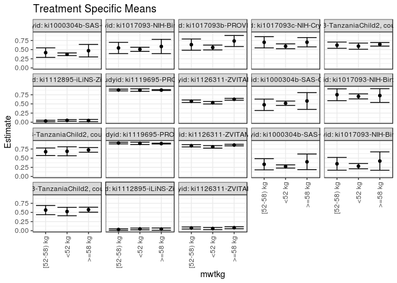

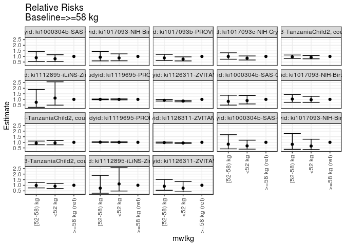

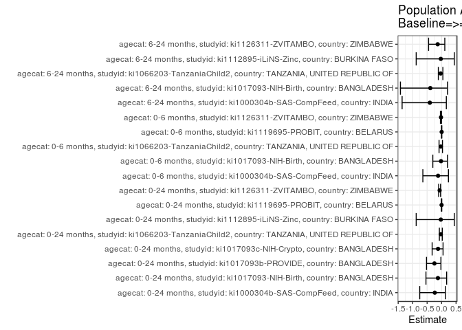

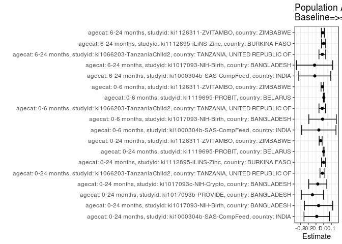

## Results Table

### Parameter: TSM

| agecat | studyid | country | intervention_level | baseline_level | estimate | ci_lower | ci_upper |
| --- | --- | --- | --- | --- | --- | --- | --- |
| 0-24 months | ki1000304b-SAS-CompFeed | INDIA | >=58 kg | NA | 0.4710493 | 0.3009978 | 0.6411007 |
| 0-24 months | ki1000304b-SAS-CompFeed | INDIA | <52 kg | NA | 0.3733084 | 0.3360813 | 0.4105355 |
| 0-24 months | ki1000304b-SAS-CompFeed | INDIA | [52-58) kg | NA | 0.4178975 | 0.2874028 | 0.5483922 |
| 0-24 months | ki1017093-NIH-Birth | BANGLADESH | >=58 kg | NA | 0.5862468 | 0.3915817 | 0.7809120 |
| 0-24 months | ki1017093-NIH-Birth | BANGLADESH | <52 kg | NA | 0.5077687 | 0.4514416 | 0.5640959 |
| 0-24 months | ki1017093-NIH-Birth | BANGLADESH | [52-58) kg | NA | 0.5457194 | 0.3927917 | 0.6986471 |
| 0-24 months | ki1017093b-PROVIDE | BANGLADESH | >=58 kg | NA | 0.7352941 | 0.5846182 | 0.8859701 |
| 0-24 months | ki1017093b-PROVIDE | BANGLADESH | <52 kg | NA | 0.5580357 | 0.4920376 | 0.6240339 |
| 0-24 months | ki1017093b-PROVIDE | BANGLADESH | [52-58) kg | NA | 0.6363636 | 0.4828843 | 0.7898430 |
| 0-24 months | ki1017093c-NIH-Crypto | BANGLADESH | >=58 kg | NA | 0.7023117 | 0.5749642 | 0.8296592 |
| 0-24 months | ki1017093c-NIH-Crypto | BANGLADESH | <52 kg | NA | 0.5913419 | 0.5255322 | 0.6571516 |
| 0-24 months | ki1017093c-NIH-Crypto | BANGLADESH | [52-58) kg | NA | 0.7004354 | 0.5472013 | 0.8536695 |
| 0-24 months | ki1066203-TanzaniaChild2 | TANZANIA, UNITED REPUBLIC OF | >=58 kg | NA | 0.6444608 | 0.5951191 | 0.6938024 |
| 0-24 months | ki1066203-TanzaniaChild2 | TANZANIA, UNITED REPUBLIC OF | <52 kg | NA | 0.5948048 | 0.5112325 | 0.6783770 |
| 0-24 months | ki1066203-TanzaniaChild2 | TANZANIA, UNITED REPUBLIC OF | [52-58) kg | NA | 0.6210876 | 0.5363419 | 0.7058333 |
| 0-24 months | ki1112895-iLiNS-Zinc | BURKINA FASO | >=58 kg | NA | 0.0446927 | 0.0135156 | 0.0758699 |
| 0-24 months | ki1112895-iLiNS-Zinc | BURKINA FASO | <52 kg | NA | 0.0500000 | 0.0272248 | 0.0727752 |
| 0-24 months | ki1112895-iLiNS-Zinc | BURKINA FASO | [52-58) kg | NA | 0.0330579 | 0.0123898 | 0.0537259 |
| 0-24 months | ki1119695-PROBIT | BELARUS | >=58 kg | NA | 0.8778135 | 0.8659807 | 0.8896463 |
| 0-24 months | ki1119695-PROBIT | BELARUS | <52 kg | NA | 0.8771648 | 0.8428066 | 0.9115230 |
| 0-24 months | ki1119695-PROBIT | BELARUS | [52-58) kg | NA | 0.8787336 | 0.8548466 | 0.9026206 |
| 0-24 months | ki1126311-ZVITAMBO | ZIMBABWE | >=58 kg | NA | 0.6259122 | 0.5997360 | 0.6520883 |
| 0-24 months | ki1126311-ZVITAMBO | ZIMBABWE | <52 kg | NA | 0.5312653 | 0.4969819 | 0.5655487 |
| 0-24 months | ki1126311-ZVITAMBO | ZIMBABWE | [52-58) kg | NA | 0.5729712 | 0.5393147 | 0.6066276 |
| 0-6 months | ki1000304b-SAS-CompFeed | INDIA | >=58 kg | NA | 0.5789474 | 0.3498480 | 0.8080467 |
| 0-6 months | ki1000304b-SAS-CompFeed | INDIA | <52 kg | NA | 0.5178571 | 0.4588483 | 0.5768660 |
| 0-6 months | ki1000304b-SAS-CompFeed | INDIA | [52-58) kg | NA | 0.4750000 | 0.3193575 | 0.6306425 |
| 0-6 months | ki1017093-NIH-Birth | BANGLADESH | >=58 kg | NA | 0.7272727 | 0.5399105 | 0.9146349 |
| 0-6 months | ki1017093-NIH-Birth | BANGLADESH | <52 kg | NA | 0.7052023 | 0.6373168 | 0.7730878 |
| 0-6 months | ki1017093-NIH-Birth | BANGLADESH | [52-58) kg | NA | 0.7500000 | 0.5885262 | 0.9114738 |
| 0-6 months | ki1066203-TanzaniaChild2 | TANZANIA, UNITED REPUBLIC OF | >=58 kg | NA | 0.7250692 | 0.6615347 | 0.7886038 |
| 0-6 months | ki1066203-TanzaniaChild2 | TANZANIA, UNITED REPUBLIC OF | <52 kg | NA | 0.6874337 | 0.5646196 | 0.8102478 |
| 0-6 months | ki1066203-TanzaniaChild2 | TANZANIA, UNITED REPUBLIC OF | [52-58) kg | NA | 0.6755098 | 0.5726195 | 0.7784000 |
| 0-6 months | ki1119695-PROBIT | BELARUS | >=58 kg | NA | 0.8982650 | 0.8869638 | 0.9095663 |
| 0-6 months | ki1119695-PROBIT | BELARUS | <52 kg | NA | 0.9033291 | 0.8720422 | 0.9346160 |
| 0-6 months | ki1119695-PROBIT | BELARUS | [52-58) kg | NA | 0.9116083 | 0.8899061 | 0.9333104 |
| 0-6 months | ki1126311-ZVITAMBO | ZIMBABWE | >=58 kg | NA | 0.8577483 | 0.8354878 | 0.8800088 |
| 0-6 months | ki1126311-ZVITAMBO | ZIMBABWE | <52 kg | NA | 0.8079698 | 0.7734916 | 0.8424480 |
| 0-6 months | ki1126311-ZVITAMBO | ZIMBABWE | [52-58) kg | NA | 0.8370752 | 0.8058580 | 0.8682925 |
| 6-24 months | ki1000304b-SAS-CompFeed | INDIA | >=58 kg | NA | 0.4000000 | 0.1876007 | 0.6123993 |
| 6-24 months | ki1000304b-SAS-CompFeed | INDIA | <52 kg | NA | 0.2733990 | 0.2292567 | 0.3175413 |
| 6-24 months | ki1000304b-SAS-CompFeed | INDIA | [52-58) kg | NA | 0.3333333 | 0.1806477 | 0.4860189 |
| 6-24 months | ki1017093-NIH-Birth | BANGLADESH | >=58 kg | NA | 0.4210526 | 0.1702652 | 0.6718400 |
| 6-24 months | ki1017093-NIH-Birth | BANGLADESH | <52 kg | NA | 0.2810458 | 0.2089924 | 0.3530991 |
| 6-24 months | ki1017093-NIH-Birth | BANGLADESH | [52-58) kg | NA | 0.3461538 | 0.1723455 | 0.5199622 |
| 6-24 months | ki1066203-TanzaniaChild2 | TANZANIA, UNITED REPUBLIC OF | >=58 kg | NA | 0.5744403 | 0.5067969 | 0.6420837 |
| 6-24 months | ki1066203-TanzaniaChild2 | TANZANIA, UNITED REPUBLIC OF | <52 kg | NA | 0.5248143 | 0.4100522 | 0.6395765 |
| 6-24 months | ki1066203-TanzaniaChild2 | TANZANIA, UNITED REPUBLIC OF | [52-58) kg | NA | 0.5642029 | 0.4389975 | 0.6894083 |
| 6-24 months | ki1112895-iLiNS-Zinc | BURKINA FASO | >=58 kg | NA | 0.0446927 | 0.0135156 | 0.0758699 |
| 6-24 months | ki1112895-iLiNS-Zinc | BURKINA FASO | <52 kg | NA | 0.0500000 | 0.0272248 | 0.0727752 |
| 6-24 months | ki1112895-iLiNS-Zinc | BURKINA FASO | [52-58) kg | NA | 0.0330579 | 0.0123898 | 0.0537259 |
| 6-24 months | ki1126311-ZVITAMBO | ZIMBABWE | >=58 kg | NA | 0.0819572 | 0.0543644 | 0.1095500 |
| 6-24 months | ki1126311-ZVITAMBO | ZIMBABWE | <52 kg | NA | 0.0608798 | 0.0315011 | 0.0902586 |
| 6-24 months | ki1126311-ZVITAMBO | ZIMBABWE | [52-58) kg | NA | 0.0749747 | 0.0466174 | 0.1033320 |

### Parameter: E(Y)

| agecat | studyid | country | intervention_level | baseline_level | estimate | ci_lower | ci_upper |
| --- | --- | --- | --- | --- | --- | --- | --- |
| 0-24 months | ki1000304b-SAS-CompFeed | INDIA | NA | NA | 0.3814815 | 0.3463355 | 0.4166275 |
| 0-24 months | ki1017093-NIH-Birth | BANGLADESH | NA | NA | 0.5201900 | 0.4695846 | 0.5707955 |
| 0-24 months | ki1017093b-PROVIDE | BANGLADESH | NA | NA | 0.5894040 | 0.5323948 | 0.6464131 |
| 0-24 months | ki1017093c-NIH-Crypto | BANGLADESH | NA | NA | 0.6258065 | 0.5718723 | 0.6797406 |
| 0-24 months | ki1066203-TanzaniaChild2 | TANZANIA, UNITED REPUBLIC OF | NA | NA | 0.6283688 | 0.5905321 | 0.6662055 |
| 0-24 months | ki1112895-iLiNS-Zinc | BURKINA FASO | NA | NA | 0.0435339 | 0.0292984 | 0.0577695 |
| 0-24 months | ki1119695-PROBIT | BELARUS | NA | NA | 0.8772681 | 0.8671551 | 0.8873812 |
| 0-24 months | ki1126311-ZVITAMBO | ZIMBABWE | NA | NA | 0.5863214 | 0.5686726 | 0.6039701 |
| 0-6 months | ki1000304b-SAS-CompFeed | INDIA | NA | NA | 0.5162242 | 0.4625356 | 0.5699128 |
| 0-6 months | ki1017093-NIH-Birth | BANGLADESH | NA | NA | 0.7130045 | 0.6535890 | 0.7724200 |
| 0-6 months | ki1066203-TanzaniaChild2 | TANZANIA, UNITED REPUBLIC OF | NA | NA | 0.7062315 | 0.6568751 | 0.7555878 |
| 0-6 months | ki1119695-PROBIT | BELARUS | NA | NA | 0.9003922 | 0.8908257 | 0.9099586 |
| 0-6 months | ki1126311-ZVITAMBO | ZIMBABWE | NA | NA | 0.8406948 | 0.8247812 | 0.8566083 |
| 6-24 months | ki1000304b-SAS-CompFeed | INDIA | NA | NA | 0.2845011 | 0.2426711 | 0.3263311 |
| 6-24 months | ki1017093-NIH-Birth | BANGLADESH | NA | NA | 0.3030303 | 0.2377927 | 0.3682679 |
| 6-24 months | ki1066203-TanzaniaChild2 | TANZANIA, UNITED REPUBLIC OF | NA | NA | 0.5570652 | 0.5044805 | 0.6096499 |
| 6-24 months | ki1112895-iLiNS-Zinc | BURKINA FASO | NA | NA | 0.0435339 | 0.0292984 | 0.0577695 |
| 6-24 months | ki1126311-ZVITAMBO | ZIMBABWE | NA | NA | 0.0722166 | 0.0562671 | 0.0881662 |

### Parameter: RR

| agecat | studyid | country | intervention_level | baseline_level | estimate | ci_lower | ci_upper |
| --- | --- | --- | --- | --- | --- | --- | --- |
| 0-24 months | ki1000304b-SAS-CompFeed | INDIA | >=58 kg | >=58 kg | 1.0000000 | 1.0000000 | 1.0000000 |
| 0-24 months | ki1000304b-SAS-CompFeed | INDIA | <52 kg | >=58 kg | 0.7925040 | 0.5448700 | 1.1526835 |
| 0-24 months | ki1000304b-SAS-CompFeed | INDIA | [52-58) kg | >=58 kg | 0.8871631 | 0.5504863 | 1.4297509 |
| 0-24 months | ki1017093-NIH-Birth | BANGLADESH | >=58 kg | >=58 kg | 1.0000000 | 1.0000000 | 1.0000000 |
| 0-24 months | ki1017093-NIH-Birth | BANGLADESH | <52 kg | >=58 kg | 0.8661347 | 0.6102335 | 1.2293480 |
| 0-24 months | ki1017093-NIH-Birth | BANGLADESH | [52-58) kg | >=58 kg | 0.9308696 | 0.6025255 | 1.4381436 |
| 0-24 months | ki1017093b-PROVIDE | BANGLADESH | >=58 kg | >=58 kg | 1.0000000 | 1.0000000 | 1.0000000 |
| 0-24 months | ki1017093b-PROVIDE | BANGLADESH | <52 kg | >=58 kg | 0.7589286 | 0.5989095 | 0.9617023 |
| 0-24 months | ki1017093b-PROVIDE | BANGLADESH | [52-58) kg | >=58 kg | 0.8654545 | 0.6305508 | 1.1878687 |
| 0-24 months | ki1017093c-NIH-Crypto | BANGLADESH | >=58 kg | >=58 kg | 1.0000000 | 1.0000000 | 1.0000000 |
| 0-24 months | ki1017093c-NIH-Crypto | BANGLADESH | <52 kg | >=58 kg | 0.8419935 | 0.6802698 | 1.0421645 |
| 0-24 months | ki1017093c-NIH-Crypto | BANGLADESH | [52-58) kg | >=58 kg | 0.9973283 | 0.7503667 | 1.3255703 |
| 0-24 months | ki1066203-TanzaniaChild2 | TANZANIA, UNITED REPUBLIC OF | >=58 kg | >=58 kg | 1.0000000 | 1.0000000 | 1.0000000 |
| 0-24 months | ki1066203-TanzaniaChild2 | TANZANIA, UNITED REPUBLIC OF | <52 kg | >=58 kg | 0.9229495 | 0.7864318 | 1.0831656 |
| 0-24 months | ki1066203-TanzaniaChild2 | TANZANIA, UNITED REPUBLIC OF | [52-58) kg | >=58 kg | 0.9637322 | 0.8241114 | 1.1270075 |
| 0-24 months | ki1112895-iLiNS-Zinc | BURKINA FASO | >=58 kg | >=58 kg | 1.0000000 | 1.0000000 | 1.0000000 |
| 0-24 months | ki1112895-iLiNS-Zinc | BURKINA FASO | <52 kg | >=58 kg | 1.1187500 | 0.4863026 | 2.5737094 |
| 0-24 months | ki1112895-iLiNS-Zinc | BURKINA FASO | [52-58) kg | >=58 kg | 0.7396694 | 0.2898718 | 1.8874236 |
| 0-24 months | ki1119695-PROBIT | BELARUS | >=58 kg | >=58 kg | 1.0000000 | 1.0000000 | 1.0000000 |
| 0-24 months | ki1119695-PROBIT | BELARUS | <52 kg | >=58 kg | 0.9992610 | 0.9587067 | 1.0415308 |
| 0-24 months | ki1119695-PROBIT | BELARUS | [52-58) kg | >=58 kg | 1.0010482 | 0.9711253 | 1.0318930 |
| 0-24 months | ki1126311-ZVITAMBO | ZIMBABWE | >=58 kg | >=58 kg | 1.0000000 | 1.0000000 | 1.0000000 |
| 0-24 months | ki1126311-ZVITAMBO | ZIMBABWE | <52 kg | >=58 kg | 0.8487857 | 0.7859324 | 0.9166656 |
| 0-24 months | ki1126311-ZVITAMBO | ZIMBABWE | [52-58) kg | >=58 kg | 0.9154179 | 0.8517169 | 0.9838831 |
| 0-6 months | ki1000304b-SAS-CompFeed | INDIA | >=58 kg | >=58 kg | 1.0000000 | 1.0000000 | 1.0000000 |
| 0-6 months | ki1000304b-SAS-CompFeed | INDIA | <52 kg | >=58 kg | 0.8944805 | 0.5925569 | 1.3502424 |
| 0-6 months | ki1000304b-SAS-CompFeed | INDIA | [52-58) kg | >=58 kg | 0.8204545 | 0.4908259 | 1.3714550 |
| 0-6 months | ki1017093-NIH-Birth | BANGLADESH | >=58 kg | >=58 kg | 1.0000000 | 1.0000000 | 1.0000000 |
| 0-6 months | ki1017093-NIH-Birth | BANGLADESH | <52 kg | >=58 kg | 0.9696532 | 0.7365063 | 1.2766045 |
| 0-6 months | ki1017093-NIH-Birth | BANGLADESH | [52-58) kg | >=58 kg | 1.0312500 | 0.7371449 | 1.4426967 |
| 0-6 months | ki1066203-TanzaniaChild2 | TANZANIA, UNITED REPUBLIC OF | >=58 kg | >=58 kg | 1.0000000 | 1.0000000 | 1.0000000 |
| 0-6 months | ki1066203-TanzaniaChild2 | TANZANIA, UNITED REPUBLIC OF | <52 kg | >=58 kg | 0.9480939 | 0.7768400 | 1.1571006 |
| 0-6 months | ki1066203-TanzaniaChild2 | TANZANIA, UNITED REPUBLIC OF | [52-58) kg | >=58 kg | 0.9316487 | 0.7813369 | 1.1108770 |
| 0-6 months | ki1119695-PROBIT | BELARUS | >=58 kg | >=58 kg | 1.0000000 | 1.0000000 | 1.0000000 |
| 0-6 months | ki1119695-PROBIT | BELARUS | <52 kg | >=58 kg | 1.0056376 | 0.9692481 | 1.0433932 |
| 0-6 months | ki1119695-PROBIT | BELARUS | [52-58) kg | >=58 kg | 1.0148544 | 0.9878864 | 1.0425587 |
| 0-6 months | ki1126311-ZVITAMBO | ZIMBABWE | >=58 kg | >=58 kg | 1.0000000 | 1.0000000 | 1.0000000 |
| 0-6 months | ki1126311-ZVITAMBO | ZIMBABWE | <52 kg | >=58 kg | 0.9419661 | 0.8960535 | 0.9902312 |
| 0-6 months | ki1126311-ZVITAMBO | ZIMBABWE | [52-58) kg | >=58 kg | 0.9758985 | 0.9325287 | 1.0212852 |
| 6-24 months | ki1000304b-SAS-CompFeed | INDIA | >=58 kg | >=58 kg | 1.0000000 | 1.0000000 | 1.0000000 |
| 6-24 months | ki1000304b-SAS-CompFeed | INDIA | <52 kg | >=58 kg | 0.6834975 | 0.3923772 | 1.1906117 |
| 6-24 months | ki1000304b-SAS-CompFeed | INDIA | [52-58) kg | >=58 kg | 0.8333333 | 0.4133009 | 1.6802394 |
| 6-24 months | ki1017093-NIH-Birth | BANGLADESH | >=58 kg | >=58 kg | 1.0000000 | 1.0000000 | 1.0000000 |
| 6-24 months | ki1017093-NIH-Birth | BANGLADESH | <52 kg | >=58 kg | 0.6674837 | 0.3488386 | 1.2771937 |
| 6-24 months | ki1017093-NIH-Birth | BANGLADESH | [52-58) kg | >=58 kg | 0.8221154 | 0.3772729 | 1.7914718 |
| 6-24 months | ki1066203-TanzaniaChild2 | TANZANIA, UNITED REPUBLIC OF | >=58 kg | >=58 kg | 1.0000000 | 1.0000000 | 1.0000000 |
| 6-24 months | ki1066203-TanzaniaChild2 | TANZANIA, UNITED REPUBLIC OF | <52 kg | >=58 kg | 0.9136099 | 0.7122828 | 1.1718422 |
| 6-24 months | ki1066203-TanzaniaChild2 | TANZANIA, UNITED REPUBLIC OF | [52-58) kg | >=58 kg | 0.9821785 | 0.7639305 | 1.2627780 |
| 6-24 months | ki1112895-iLiNS-Zinc | BURKINA FASO | >=58 kg | >=58 kg | 1.0000000 | 1.0000000 | 1.0000000 |
| 6-24 months | ki1112895-iLiNS-Zinc | BURKINA FASO | <52 kg | >=58 kg | 1.1187500 | 0.4863026 | 2.5737094 |
| 6-24 months | ki1112895-iLiNS-Zinc | BURKINA FASO | [52-58) kg | >=58 kg | 0.7396694 | 0.2898718 | 1.8874236 |
| 6-24 months | ki1126311-ZVITAMBO | ZIMBABWE | >=58 kg | >=58 kg | 1.0000000 | 1.0000000 | 1.0000000 |
| 6-24 months | ki1126311-ZVITAMBO | ZIMBABWE | <52 kg | >=58 kg | 0.7428249 | 0.4121498 | 1.3388064 |
| 6-24 months | ki1126311-ZVITAMBO | ZIMBABWE | [52-58) kg | >=58 kg | 0.9148030 | 0.5512215 | 1.5182003 |

### Parameter: PAR

| agecat | studyid | country | intervention_level | baseline_level | estimate | ci_lower | ci_upper |
| --- | --- | --- | --- | --- | --- | --- | --- |
| 0-24 months | ki1000304b-SAS-CompFeed | INDIA | >=58 kg | NA | -0.0895678 | -0.2551756 | 0.0760400 |
| 0-24 months | ki1017093-NIH-Birth | BANGLADESH | >=58 kg | NA | -0.0660568 | -0.2496548 | 0.1175412 |
| 0-24 months | ki1017093b-PROVIDE | BANGLADESH | >=58 kg | NA | -0.1458901 | -0.2895446 | -0.0022357 |
| 0-24 months | ki1017093c-NIH-Crypto | BANGLADESH | >=58 kg | NA | -0.0765053 | -0.1935527 | 0.0405422 |
| 0-24 months | ki1066203-TanzaniaChild2 | TANZANIA, UNITED REPUBLIC OF | >=58 kg | NA | -0.0160920 | -0.0477047 | 0.0155207 |
| 0-24 months | ki1112895-iLiNS-Zinc | BURKINA FASO | >=58 kg | NA | -0.0011588 | -0.0281611 | 0.0258435 |
| 0-24 months | ki1119695-PROBIT | BELARUS | >=58 kg | NA | -0.0005454 | -0.0066587 | 0.0055680 |
| 0-24 months | ki1126311-ZVITAMBO | ZIMBABWE | >=58 kg | NA | -0.0395908 | -0.0588780 | -0.0203036 |
| 0-6 months | ki1000304b-SAS-CompFeed | INDIA | >=58 kg | NA | -0.0627232 | -0.2851766 | 0.1597303 |
| 0-6 months | ki1017093-NIH-Birth | BANGLADESH | >=58 kg | NA | -0.0142682 | -0.1923365 | 0.1638001 |
| 0-6 months | ki1066203-TanzaniaChild2 | TANZANIA, UNITED REPUBLIC OF | >=58 kg | NA | -0.0188378 | -0.0606288 | 0.0229533 |
| 0-6 months | ki1119695-PROBIT | BELARUS | >=58 kg | NA | 0.0021271 | -0.0035058 | 0.0077600 |
| 0-6 months | ki1126311-ZVITAMBO | ZIMBABWE | >=58 kg | NA | -0.0170535 | -0.0338988 | -0.0002082 |
| 6-24 months | ki1000304b-SAS-CompFeed | INDIA | >=58 kg | NA | -0.1154989 | -0.3229953 | 0.0919975 |
| 6-24 months | ki1017093-NIH-Birth | BANGLADESH | >=58 kg | NA | -0.1180223 | -0.3533429 | 0.1172982 |
| 6-24 months | ki1066203-TanzaniaChild2 | TANZANIA, UNITED REPUBLIC OF | >=58 kg | NA | -0.0173751 | -0.0609749 | 0.0262247 |
| 6-24 months | ki1112895-iLiNS-Zinc | BURKINA FASO | >=58 kg | NA | -0.0011588 | -0.0281611 | 0.0258435 |
| 6-24 months | ki1126311-ZVITAMBO | ZIMBABWE | >=58 kg | NA | -0.0097405 | -0.0299794 | 0.0104983 |

### Parameter: PAF

| agecat | studyid | country | intervention_level | baseline_level | estimate | ci_lower | ci_upper |
| --- | --- | --- | --- | --- | --- | --- | --- |
| 0-24 months | ki1000304b-SAS-CompFeed | INDIA | >=58 kg | NA | -0.2347893 | -0.7550955 | 0.1312697 |
| 0-24 months | ki1017093-NIH-Birth | BANGLADESH | >=58 kg | NA | -0.1269859 | -0.5402644 | 0.1754031 |
| 0-24 months | ki1017093b-PROVIDE | BANGLADESH | >=58 kg | NA | -0.2475215 | -0.5202035 | -0.0237510 |
| 0-24 months | ki1017093c-NIH-Crypto | BANGLADESH | >=58 kg | NA | -0.1222507 | -0.3265097 | 0.0505561 |
| 0-24 months | ki1066203-TanzaniaChild2 | TANZANIA, UNITED REPUBLIC OF | >=58 kg | NA | -0.0256091 | -0.0771950 | 0.0235064 |
| 0-24 months | ki1112895-iLiNS-Zinc | BURKINA FASO | >=58 kg | NA | -0.0266185 | -0.8777261 | 0.4387118 |
| 0-24 months | ki1119695-PROBIT | BELARUS | >=58 kg | NA | -0.0006217 | -0.0076146 | 0.0063227 |
| 0-24 months | ki1126311-ZVITAMBO | ZIMBABWE | >=58 kg | NA | -0.0675240 | -0.1009907 | -0.0350746 |
| 0-6 months | ki1000304b-SAS-CompFeed | INDIA | >=58 kg | NA | -0.1215038 | -0.6471022 | 0.2363736 |
| 0-6 months | ki1017093-NIH-Birth | BANGLADESH | >=58 kg | NA | -0.0200114 | -0.3030056 | 0.2015204 |
| 0-6 months | ki1066203-TanzaniaChild2 | TANZANIA, UNITED REPUBLIC OF | >=58 kg | NA | -0.0266737 | -0.0876878 | 0.0309179 |
| 0-6 months | ki1119695-PROBIT | BELARUS | >=58 kg | NA | 0.0023624 | -0.0039144 | 0.0086000 |
| 0-6 months | ki1126311-ZVITAMBO | ZIMBABWE | >=58 kg | NA | -0.0202850 | -0.0405545 | -0.0004104 |
| 6-24 months | ki1000304b-SAS-CompFeed | INDIA | >=58 kg | NA | -0.4059701 | -1.3642228 | 0.1638893 |
| 6-24 months | ki1017093-NIH-Birth | BANGLADESH | >=58 kg | NA | -0.3894737 | -1.4221313 | 0.2029181 |
| 6-24 months | ki1066203-TanzaniaChild2 | TANZANIA, UNITED REPUBLIC OF | >=58 kg | NA | -0.0311904 | -0.1126265 | 0.0442852 |
| 6-24 months | ki1112895-iLiNS-Zinc | BURKINA FASO | >=58 kg | NA | -0.0266185 | -0.8777261 | 0.4387118 |
| 6-24 months | ki1126311-ZVITAMBO | ZIMBABWE | >=58 kg | NA | -0.1348794 | -0.4490291 | 0.1111626 |